# Project: Wrangle and Analyze Data

- Introduction
- Gathering Data
- Assessing Data
- Cleaning Data
- Cleaned Data
- Analyze and visualize Data

## Introduction

>

>

> Dataset used from WeRateDogs, a Twitter account that rates people's dogs with a humorous comment about the dog. These ratings almost always have a denominator of 10. The numerators, though? Almost always greater than 10. 11/10, 12/10, 13/10, etc. Why? Because "they're good dogs Brent." WeRateDogs has over 9 million followers and has received international media coverage.

## Gathering Data

##### import needed libraries:

```python
import numpy as np
import pandas as pd
import requests
```

##### download and save images data:

```python
url = 'https://d17h27t6h515a5.cloudfront.net/topher/2017/August/599fd2ad_image-predictions/image-predictions.tsv'

response = requests.get(url)

with open (url.split('/')[-1] , mode = 'wb') as outfile:
    outfile.write(response.content)
```

##### load files:

```python
archive_df = pd.read_csv('twitter-archive-enhanced-2.csv')

images_df = pd.read_csv('image-predictions.tsv' , sep = '\t')

tweet_df = pd.read_json('tweet-json copy' , lines = True)
```

## Assessing Data

- Visual Assessment Assessing_tweet table
- Programmatic Assessing_tweet table
- Visual Assessing image_df table
- Programmatic Assessing image_df table
- Assessment summary
- before we start i will drop coulmns that are not needed in this project and merge tweet_df and archive_df

```python
archive_df.drop(columns=['in_reply_to_status_id', 'in_reply_to_user_id', 'timestamp','retweeted_status_user_id',
                         'retweeted_status_timestamp','expanded_urls','source'] , inplace=True)
tweet_df.drop(columns=['id_str','full_text', 'truncated','display_text_range','entities','source','in_reply_to_status_id',
                       'in_reply_to_status_id_str','in_reply_to_user_id', 'in_reply_to_user_id_str','in_reply_to_screen_name', 'user', 'geo', 'coordinates', 'place',
                       'contributors', 'is_quote_status','favorited','retweeted','possibly_sensitive','possibly_sensitive_appealable',
                        'lang', 'quoted_status_id', 'quoted_status_id_str', 'quoted_status' ] , inplace=True)
```

```python
# using merge method to merge tweet dataframe and archive dataframe in Assessing_tweet dataframe if they have same id

Assessing_tweet = pd.merge(tweet_df, archive_df , left_on='id' , right_on='tweet_id')
```

```python
# drop tweet_id column from Assessing_tweet

Assessing_tweet.drop(columns=['tweet_id'],inplace=True)
```

##### (Assessing_tweet) Visual Assessment

```python
Assessing_tweet
```

|  | created_at | id | extended_entities | retweet_count | favorite_count | retweeted_status | text | retweeted_status_id | rating_numerator | rating_denominator | name | doggo | floofer | pupper | puppo |
| --- | --- | --- | --- | --- | --- | --- | --- | --- | --- | --- | --- | --- | --- | --- | --- |
| 0 | 2017-08-01 16:23:56+00:00 | 892420643555336193 | {'media': [{'id': 892420639486877696, 'id_str'... | 8853 | 39467 | NaN | This is Phineas. He's a mystical boy. Only eve... | NaN | 13 | 10 | Phineas | None | None | None | None |
| 1 | 2017-08-01 00:17:27+00:00 | 892177421306343426 | {'media': [{'id': 892177413194625024, 'id_str'... | 6514 | 33819 | NaN | This is Tilly. She's just checking pup on you.... | NaN | 13 | 10 | Tilly | None | None | None | None |
| 2 | 2017-07-31 00:18:03+00:00 | 891815181378084864 | {'media': [{'id': 891815175371796480, 'id_str'... | 4328 | 25461 | NaN | This is Archie. He is a rare Norwegian Pouncin... | NaN | 12 | 10 | Archie | None | None | None | None |
| 3 | 2017-07-30 15:58:51+00:00 | 891689557279858688 | {'media': [{'id': 891689552724799489, 'id_str'... | 8964 | 42908 | NaN | This is Darla. She commenced a snooze mid meal... | NaN | 13 | 10 | Darla | None | None | None | None |
| 4 | 2017-07-29 16:00:24+00:00 | 891327558926688256 | {'media': [{'id': 891327551943041024, 'id_str'... | 9774 | 41048 | NaN | This is Franklin. He would like you to stop ca... | NaN | 12 | 10 | Franklin | None | None | None | None |
| ... | ... | ... | ... | ... | ... | ... | ... | ... | ... | ... | ... | ... | ... | ... | ... |
| 2349 | 2015-11-16 00:24:50+00:00 | 666049248165822465 | {'media': [{'id': 666049244999131136, 'id_str'... | 41 | 111 | NaN | Here we have a 1949 1st generation vulpix. Enj... | NaN | 5 | 10 | None | None | None | None | None |
| 2350 | 2015-11-16 00:04:52+00:00 | 666044226329800704 | {'media': [{'id': 666044217047650304, 'id_str'... | 147 | 311 | NaN | This is a purebred Piers Morgan. Loves to Netf... | NaN | 6 | 10 | a | None | None | None | None |
| 2351 | 2015-11-15 23:21:54+00:00 | 666033412701032449 | {'media': [{'id': 666033409081393153, 'id_str'... | 47 | 128 | NaN | Here is a very happy pup. Big fan of well-main... | NaN | 9 | 10 | a | None | None | None | None |
| 2352 | 2015-11-15 23:05:30+00:00 | 666029285002620928 | {'media': [{'id': 666029276303482880, 'id_str'... | 48 | 132 | NaN | This is a western brown Mitsubishi terrier. Up... | NaN | 7 | 10 | a | None | None | None | None |
| 2353 | 2015-11-15 22:32:08+00:00 | 666020888022790149 | {'media': [{'id': 666020881337073664, 'id_str'... | 532 | 2535 | NaN | Here we have a Japanese Irish Setter. Lost eye... | NaN | 8 | 10 | None | None | None | None | None |

2354 rows × 15 columns

- I notice that we have names that only have (a)
- created_at we need the month and year in separated column to use it in visualization
- we have missing values in dogs stages need to check
- doggo , floofer , pupper and puppo columns need to be variables in one columns called dog_stages

##### (Assessing_tweet) Programmatic Assessment

```python
Assessing_tweet.info()
```

```
<class 'pandas.core.frame.DataFrame'>
Int64Index: 2354 entries, 0 to 2353
Data columns (total 15 columns):
 #   Column               Non-Null Count  Dtype
---  ------               --------------  -----
 0   created_at           2354 non-null   datetime64[ns, UTC]
 1   id                   2354 non-null   int64
 2   extended_entities    2073 non-null   object
 3   retweet_count        2354 non-null   int64
 4   favorite_count       2354 non-null   int64
 5   retweeted_status     179 non-null    object
 6   text                 2354 non-null   object
 7   retweeted_status_id  179 non-null    float64
 8   rating_numerator     2354 non-null   int64
 9   rating_denominator   2354 non-null   int64
 10  name                 2354 non-null   object
 11  doggo                2354 non-null   object
 12  floofer              2354 non-null   object
 13  pupper               2354 non-null   object
 14  puppo                2354 non-null   object
dtypes: datetime64[ns, UTC](1), float64(1), int64(5), object(8)
memory usage: 294.2+ KB
```

- id should be string not intger
- we have 179 tweets that are retweeted need to drop

```python
Assessing_tweet.describe()
```

|  | id | retweet_count | favorite_count | retweeted_status_id | rating_numerator | rating_denominator |
| --- | --- | --- | --- | --- | --- | --- |
| count | 2.354000e+03 | 2354.000000 | 2354.000000 | 1.790000e+02 | 2354.000000 | 2354.00000 |
| mean | 7.426978e+17 | 3164.797366 | 8080.968564 | 7.714009e+17 | 13.127018 | 10.45582 |
| std | 6.852812e+16 | 5284.770364 | 11814.771334 | 6.211568e+16 | 45.896135 | 6.74809 |
| min | 6.660209e+17 | 0.000000 | 0.000000 | 6.661041e+17 | 0.000000 | 0.00000 |
| 25% | 6.783975e+17 | 624.500000 | 1415.000000 | 7.157203e+17 | 10.000000 | 10.00000 |
| 50% | 7.194596e+17 | 1473.500000 | 3603.500000 | 7.804657e+17 | 11.000000 | 10.00000 |
| 75% | 7.993058e+17 | 3652.000000 | 10122.250000 | 8.201334e+17 | 12.000000 | 10.00000 |
| max | 8.924206e+17 | 79515.000000 | 132810.000000 | 8.860537e+17 | 1776.000000 | 170.00000 |

- rating_denominator have max value of 170 and min value of 0 should be 10
- we have tweet with no retweet or favorite (will be fixed after merged)

##### know I go deep in some columns:

1- Rating:

see why there are rating_denominator not equal to 10

```python
# store index rows that have rating_denominator not equal 10
not_ten = list(Assessing_tweet[Assessing_tweet['rating_denominator'] != 10].index)

# displays their text to absorave the issues
for i in not_ten:
    print(i , '-',Assessing_tweet['text'][i])
```

```
312 - @jonnysun @Lin_Manuel ok jomny I know you're excited but 960/00 isn't a valid rating, 13/10 is tho
341 - @docmisterio account started on 11/15/15
432 - The floofs have been released I repeat the floofs have been released. 84/70 https://t.co/NIYC820tmd
515 - Meet Sam. She smiles 24/7 &amp; secretly aspires to be a reindeer.
Keep Sam smiling by clicking and sharing this link:
https://t.co/98tB8y7y7t https://t.co/LouL5vdvxx
783 - RT @dog_rates: After so many requests, this is Bretagne. She was the last surviving 9/11 search dog, and our second ever 14/10. RIP https:/…
900 - Why does this never happen at my front door... 165/150 https://t.co/HmwrdfEfUE
1066 - After so many requests, this is Bretagne. She was the last surviving 9/11 search dog, and our second ever 14/10. RIP https://t.co/XAVDNDaVgQ
1118 - Say hello to this unbelievably well behaved squad of doggos. 204/170 would try to pet all at once https://t.co/yGQI3He3xv
1163 - Happy 4/20 from the squad! 13/10 for all https://t.co/eV1diwds8a
1200 - This is Bluebert. He just saw that both #FinalFur match ups are split 50/50. Amazed af. 11/10 https://t.co/Kky1DPG4iq
1226 - Happy Saturday here's 9 puppers on a bench. 99/90 good work everybody https://t.co/mpvaVxKmc1
1252 - Here's a brigade of puppers. All look very prepared for whatever happens next. 80/80 https://t.co/0eb7R1Om12
1272 - From left to right:
Cletus, Jerome, Alejandro, Burp, &amp; Titson
None know where camera is. 45/50 would hug all at once https://t.co/sedre1ivTK
1349 - Here is a whole flock of puppers.  60/50 I'll take the lot https://t.co/9dpcw6MdWa
1431 - Happy Wednesday here's a bucket of pups. 44/40 would pet all at once https://t.co/HppvrYuamZ
1596 - Yes I do realize a rating of 4/20 would've been fitting. However, it would be unjust to give these cooperative pups that low of a rating
1632 - Two sneaky puppers were not initially seen, moving the rating to 143/130. Please forgive us. Thank you https://t.co/kRK51Y5ac3
1633 - Someone help the girl is being mugged. Several are distracting her while two steal her shoes. Clever puppers 121/110 https://t.co/1zfnTJLt55
1660 - This is Darrel. He just robbed a 7/11 and is in a high speed police chase. Was just spotted by the helicopter 10/10 https://t.co/7EsP8LmSp5
1661 - I'm aware that I could've said 20/16, but here at WeRateDogs we are very professional. An inconsistent rating scale is simply irresponsible
1777 - IT'S PUPPERGEDDON. Total of 144/120 ...I think https://t.co/ZanVtAtvIq
1841 - Here we have an entire platoon of puppers. Total score: 88/80 would pet all at once https://t.co/y93p6FLvVw
2333 - This is an Albanian 3 1/2 legged  Episcopalian. Loves well-polished hardwood flooring. Penis on the collar. 9/10 https://t.co/d9NcXFKwLv
```

#### it seems that extractor extract the number before and after first /

we have rating_denominator that not equal 10 and it seems that many reasons:

- The rating includes more than one dog
- There where date or not actual rating (joking) that contain / before the rating
- some tweet is not dog tweet (it will be fixed when I merge the data frame with images data frame)

Try to find pattren to make rating clean easier

```python
# i tried more than rating number to isolated the rating that for more than one dog and i find that 40 is the answer
above_40 = list(Assessing_tweet[Assessing_tweet['rating_denominator'] >= 40].index)

# displays their text to absorave the issues
for i in above_40:
    print(i , '-',Assessing_tweet['text'][i])
```

```
432 - The floofs have been released I repeat the floofs have been released. 84/70 https://t.co/NIYC820tmd
900 - Why does this never happen at my front door... 165/150 https://t.co/HmwrdfEfUE
1118 - Say hello to this unbelievably well behaved squad of doggos. 204/170 would try to pet all at once https://t.co/yGQI3He3xv
1200 - This is Bluebert. He just saw that both #FinalFur match ups are split 50/50. Amazed af. 11/10 https://t.co/Kky1DPG4iq
1226 - Happy Saturday here's 9 puppers on a bench. 99/90 good work everybody https://t.co/mpvaVxKmc1
1252 - Here's a brigade of puppers. All look very prepared for whatever happens next. 80/80 https://t.co/0eb7R1Om12
1272 - From left to right:
Cletus, Jerome, Alejandro, Burp, &amp; Titson
None know where camera is. 45/50 would hug all at once https://t.co/sedre1ivTK
1349 - Here is a whole flock of puppers.  60/50 I'll take the lot https://t.co/9dpcw6MdWa
1431 - Happy Wednesday here's a bucket of pups. 44/40 would pet all at once https://t.co/HppvrYuamZ
1632 - Two sneaky puppers were not initially seen, moving the rating to 143/130. Please forgive us. Thank you https://t.co/kRK51Y5ac3
1633 - Someone help the girl is being mugged. Several are distracting her while two steal her shoes. Clever puppers 121/110 https://t.co/1zfnTJLt55
1777 - IT'S PUPPERGEDDON. Total of 144/120 ...I think https://t.co/ZanVtAtvIq
1841 - Here we have an entire platoon of puppers. Total score: 88/80 would pet all at once https://t.co/y93p6FLvVw
```

- any tweet have more than 40 in rating_denominator include more than one dog
- index 1200 have more than 50 but have wrog value

```python
# find index 1200 index:
Assessing_tweet['id'][1200]
```

```
716439118184652801
```

- id = 716439118184652801 have more than 50 but have wrog value

Lets see the other rating_denominator that less than 40 and not 10

```python
# rows that have rating denominator that less than 40 and not 10
other_rating = (list(Assessing_tweet[(Assessing_tweet['rating_denominator'] < 40)&(Assessing_tweet['rating_denominator'] != 10)].index) )

# displays their text to absorave the issues
for i in other_rating:
    print(i , '-',Assessing_tweet['text'][i])
```

```
312 - @jonnysun @Lin_Manuel ok jomny I know you're excited but 960/00 isn't a valid rating, 13/10 is tho
341 - @docmisterio account started on 11/15/15
515 - Meet Sam. She smiles 24/7 &amp; secretly aspires to be a reindeer.
Keep Sam smiling by clicking and sharing this link:
https://t.co/98tB8y7y7t https://t.co/LouL5vdvxx
783 - RT @dog_rates: After so many requests, this is Bretagne. She was the last surviving 9/11 search dog, and our second ever 14/10. RIP https:/…
1066 - After so many requests, this is Bretagne. She was the last surviving 9/11 search dog, and our second ever 14/10. RIP https://t.co/XAVDNDaVgQ
1163 - Happy 4/20 from the squad! 13/10 for all https://t.co/eV1diwds8a
1596 - Yes I do realize a rating of 4/20 would've been fitting. However, it would be unjust to give these cooperative pups that low of a rating
1660 - This is Darrel. He just robbed a 7/11 and is in a high speed police chase. Was just spotted by the helicopter 10/10 https://t.co/7EsP8LmSp5
1661 - I'm aware that I could've said 20/16, but here at WeRateDogs we are very professional. An inconsistent rating scale is simply irresponsible
2333 - This is an Albanian 3 1/2 legged  Episcopalian. Loves well-polished hardwood flooring. Penis on the collar. 9/10 https://t.co/d9NcXFKwLv
```

- Any dog than have less than 40 and not equal to 10 rating_denominator the tweet have date or not actual rating (joking) that contain / before the rating
- index 515 with name of sam has no rating
- some tweet are not rating it will be dropped when i merge the images data frame to this data frame

```python
# find index 515 index:
Assessing_tweet['id'][515]
```

```
810984652412424192
```

enough of rating_denominator lets see the rating_numerator:

lets check the text of high rating and the low ones:

```python
# rows that have rating numerator that taht more than 20
above_20 = list(Assessing_tweet[(Assessing_tweet['rating_numerator'] > 20)&(Assessing_tweet['rating_denominator'] == 10)].index)

# displays their text to absorave the issues
for i in above_20:
    print(i , '-',Assessing_tweet['text'][i])
```

```
187 - @dhmontgomery We also gave snoop dogg a 420/10 but I think that predated your research
188 - @s8n You tried very hard to portray this good boy as not so good, but you have ultimately failed. His goodness shines through. 666/10
289 - @markhoppus 182/10
339 - RT @dog_rates: This is Logan, the Chow who lived. He solemnly swears he's up to lots of good. H*ckin magical af 9.75/10 https://t.co/yBO5wu…
694 - This is Logan, the Chow who lived. He solemnly swears he's up to lots of good. H*ckin magical af 9.75/10 https://t.co/yBO5wuqaPS
762 - This is Sophie. She's a Jubilant Bush Pupper. Super h*ckin rare. Appears at random just to smile at the locals. 11.27/10 would smile back https://t.co/QFaUiIHxHq
977 - This is Atticus. He's quite simply America af. 1776/10 https://t.co/GRXwMxLBkh
1710 - Here we have uncovered an entire battalion of holiday puppers. Average of 11.26/10 https://t.co/eNm2S6p9BD
2072 - After so many requests... here you go.

Good dogg. 420/10 https://t.co/yfAAo1gdeY
```

- some rating_numerator have decimal value are becoming invalid because it took numbers after the digit
- rating_numerator need to be converted to float

```python
# rows that have rating numerator that taht more less 2
less_2 = list(Assessing_tweet[(Assessing_tweet['rating_numerator'] < 2 )&(Assessing_tweet['rating_denominator'] == 10)].index)

# displays their text to absorave the issues
for i in less_2:
    print(i , '-',Assessing_tweet['text'][i])
```

```
314 - When you're so blinded by your systematic plagiarism that you forget what day it is. 0/10 https://t.co/YbEJPkg4Ag
604 - RT @dog_rates: Not familiar with this breed. No tail (weird). Only 2 legs. Doesn't bark. Surprisingly quick. Shits eggs. 1/10 https://t.co/…
1014 - PUPDATE: can't see any. Even if I could, I couldn't reach them to pet. 0/10 much disappointment https://t.co/c7WXaB2nqX
1444 - After reading the comments I may have overestimated this pup. Downgraded to a 1/10. Please forgive me
1867 - What kind of person sends in a picture without a dog in it? 1/10 just because that's a nice table https://t.co/RDXCfk8hK0
1938 - The millennials have spoken and we've decided to immediately demote to a 1/10. Thank you
2036 - After 22 minutes of careful deliberation this dog is being demoted to a 1/10. The longer you look at him the more terrifying he becomes
2089 - Flamboyant pup here. Probably poisonous. Won't eat kibble. Doesn't bark. Slow af. Petting doesn't look fun. 1/10 https://t.co/jxukeh2BeO
2259 - Never seen dog like this. Breathes heavy. Tilts head in a pattern. No bark. Shitty at fetch. Not even cordless. 1/10 https://t.co/i9iSGNn3fx
2336 - Not familiar with this breed. No tail (weird). Only 2 legs. Doesn't bark. Surprisingly quick. Shits eggs. 1/10 https://t.co/Asgdc6kuLX
```

- some rating have zero witch doesnt make snece need to be check

2- names:

```python
Assessing_tweet['name'].value_counts()
```

```
None        744
a            55
Charlie      12
Oliver       11
Cooper       11
           ...
Luther        1
Jomathan      1
Rorie         1
Bowie         1
Mary          1
Name: name, Length: 957, dtype: int64
```

check the names that have a

```python
Assessing_tweet[Assessing_tweet['name'] == 'a'].text[1000]
```

```
'This is a mighty rare blue-tailed hammer sherk. Human almost lost a limb trying to take these. Be careful guys. 8/10 https://t.co/TGenMeXreW'
```

- it seems names was extracted after the substring 'this is' and some tweet has (a) after 'is'

  > the problem in is case the (a) followed by adjective not name which make it so hard but I notice that many texts contain named after the adj so I use these.

check an also:

```python
Assessing_tweet[Assessing_tweet['name'] == 'an']['id'].count()
```

```
7
```

- Also an has the same thing like a

the also popslibe to come after (this is)

```python
Assessing_tweet[Assessing_tweet['name'] == 'the']['id'].count()
```

```
8
```

- Also (the) has the same thing like a

3- checking dog stages

```python
## see how many null value in doggo:
(Assessing_tweet['floofer'] != 'None').sum()
```

```
10
```

```python
## see how many doggo value in the text:
counter = 0
for i in Assessing_tweet.index:
    if(('floof' in Assessing_tweet['text'][i])|('Floof' in Assessing_tweet['text'][i])):
        counter += 1

counter
```

```
41
```

- not all dog stages have extracted right i think the lowwer and upper cases have effected this so text need to be in lowewr case to extract more effictivly.

4- extended_entities:

```python
Assessing_tweet['extended_entities'][0]
```

```
{'media': [{'id': 892420639486877696,
   'id_str': '892420639486877696',
   'indices': [86, 109],
   'media_url': 'http://pbs.twimg.com/media/DGKD1-bXoAAIAUK.jpg',
   'media_url_https': 'https://pbs.twimg.com/media/DGKD1-bXoAAIAUK.jpg',
   'url': 'https://t.co/MgUWQ76dJU',
   'display_url': 'pic.twitter.com/MgUWQ76dJU',
   'expanded_url': 'https://twitter.com/dog_rates/status/892420643555336193/photo/1',
   'type': 'photo',
   'sizes': {'large': {'w': 540, 'h': 528, 'resize': 'fit'},
    'thumb': {'w': 150, 'h': 150, 'resize': 'crop'},
    'small': {'w': 540, 'h': 528, 'resize': 'fit'},
    'medium': {'w': 540, 'h': 528, 'resize': 'fit'}}}]}
```

- we only need the tweet url from this so we can go back to the source if needed

##### (images_df) Visual Assessment

```python
images_df
```

|  | tweet_id | jpg_url | img_num | p1 | p1_conf | p1_dog | p2 | p2_conf | p2_dog | p3 | p3_conf | p3_dog |
| --- | --- | --- | --- | --- | --- | --- | --- | --- | --- | --- | --- | --- |
| 0 | 666020888022790149 | https://pbs.twimg.com/media/CT4udn0WwAA0aMy.jpg | 1 | Welsh_springer_spaniel | 0.465074 | True | collie | 0.156665 | True | Shetland_sheepdog | 0.061428 | True |
| 1 | 666029285002620928 | https://pbs.twimg.com/media/CT42GRgUYAA5iDo.jpg | 1 | redbone | 0.506826 | True | miniature_pinscher | 0.074192 | True | Rhodesian_ridgeback | 0.072010 | True |
| 2 | 666033412701032449 | https://pbs.twimg.com/media/CT4521TWwAEvMyu.jpg | 1 | German_shepherd | 0.596461 | True | malinois | 0.138584 | True | bloodhound | 0.116197 | True |
| 3 | 666044226329800704 | https://pbs.twimg.com/media/CT5Dr8HUEAA-lEu.jpg | 1 | Rhodesian_ridgeback | 0.408143 | True | redbone | 0.360687 | True | miniature_pinscher | 0.222752 | True |
| 4 | 666049248165822465 | https://pbs.twimg.com/media/CT5IQmsXIAAKY4A.jpg | 1 | miniature_pinscher | 0.560311 | True | Rottweiler | 0.243682 | True | Doberman | 0.154629 | True |
| ... | ... | ... | ... | ... | ... | ... | ... | ... | ... | ... | ... | ... |
| 2070 | 891327558926688256 | https://pbs.twimg.com/media/DF6hr6BUMAAzZgT.jpg | 2 | basset | 0.555712 | True | English_springer | 0.225770 | True | German_short-haired_pointer | 0.175219 | True |
| 2071 | 891689557279858688 | https://pbs.twimg.com/media/DF_q7IAWsAEuuN8.jpg | 1 | paper_towel | 0.170278 | False | Labrador_retriever | 0.168086 | True | spatula | 0.040836 | False |
| 2072 | 891815181378084864 | https://pbs.twimg.com/media/DGBdLU1WsAANxJ9.jpg | 1 | Chihuahua | 0.716012 | True | malamute | 0.078253 | True | kelpie | 0.031379 | True |
| 2073 | 892177421306343426 | https://pbs.twimg.com/media/DGGmoV4XsAAUL6n.jpg | 1 | Chihuahua | 0.323581 | True | Pekinese | 0.090647 | True | papillon | 0.068957 | True |
| 2074 | 892420643555336193 | https://pbs.twimg.com/media/DGKD1-bXoAAIAUK.jpg | 1 | orange | 0.097049 | False | bagel | 0.085851 | False | banana | 0.076110 | False |

2075 rows × 12 columns

- There are some rows that all algorithms agree to be not a dog so needs to be dropped
- the highest algorithm conf of the dog type need to be in new columns named dog type

##### (images_df) Programmatic Assessment

```python
# see how many tweet are not dog tweet
((images_df['p1_dog'] == False)& (images_df['p2_dog'] == False) & (images_df['p3_dog'] == False)).sum()
```

```
324
```

- we have 324 rows that they are not dog , needed to be dropped

### Assessment summary :

### Quality:

**Assessing_tweet table:**

- id is intger intger not string.
- text have inconsistent format (lowercase and uppercase).
- there are 179 tweets that are retweeted.
- tweets that have more than 40 in rating_denominator include more than one dog.
- id:716439118184652801 have more than 40 in rating_denominator but include one dog.
- tweets that have less than 40 and not equal to 10 rating_denominator contain slash before the rating slash.
- id:810984652412424192 has no rating
- rating_numerator is intger not float.
- some tweet have rating_numerator as decimal value.
- some tweet have rating_numerator as zero
- some name have name of (a) , (an) or (the).
- dog stage in text more than in each doggo,floofer,pupper,and puppo variables.

**images table:**

- in some cases all algorithms agreed that a tweet is not dog rating tweet.
- no column for the dog type based on highest algorithm prediction.

### Tidiness:

**Assessing_tweet table:**

- month and year in created_at are not separated.
- doggo,floofer,pupper,and puppo variables are not in one column.
- tweet url inside extended_entities are not in spareted column.

### Cleaning Data

- cleaning image data frame
- cleaning tweet data frame

```python
# taking copy for each data so we can go back to the messy data after cleaning
cleaning_tweet = Assessing_tweet.copy()
cleaning_image = images_df.copy()
```

#### 1- cleaning image data frame

```python
cleaning_image.info()
```

```
<class 'pandas.core.frame.DataFrame'>
RangeIndex: 2075 entries, 0 to 2074
Data columns (total 12 columns):
 #   Column    Non-Null Count  Dtype
---  ------    --------------  -----
 0   tweet_id  2075 non-null   int64
 1   jpg_url   2075 non-null   object
 2   img_num   2075 non-null   int64
 3   p1        2075 non-null   object
 4   p1_conf   2075 non-null   float64
 5   p1_dog    2075 non-null   bool
 6   p2        2075 non-null   object
 7   p2_conf   2075 non-null   float64
 8   p2_dog    2075 non-null   bool
 9   p3        2075 non-null   object
 10  p3_conf   2075 non-null   float64
 11  p3_dog    2075 non-null   bool
dtypes: bool(3), float64(3), int64(2), object(4)
memory usage: 152.1+ KB
```

##### drop any tweet that have agreement from all three algorithms that is not dog.

```python
# fliter out any tweet that have three false in p_dog
cleaning_image = cleaning_image[(cleaning_image['p1_dog'] == True) | (cleaning_image['p2_dog'] == True)
                    | (cleaning_image['p3_dog'] == True) ]
```

```python
# test if the code worked:
((cleaning_image['p1_dog'] == False) & (cleaning_image['p2_dog'] == False) & (cleaning_image['p3_dog'] == False)).sum()
```

```
0
```

it worked and we dropped any tweet that algorithms predicted to be not a dog.

##### add column named dog_type, the type of dog will be taken from the algorithm that has highest confident rate and true to be a dog.

```python
# this list will store each dog type
dog_type = []

# this var will usesd to compared and hold the highest confident rate
# >> highest

# this var will hold the index of highest confident p{-}.conf
# >> hold_coulums

# this nested loop will go through each index and in each index it will go through each p{}_dog and check if it true
# then compare it with prevoius p{}_conf (if there wasnt prevouis one it will set the frist as highest)
# and hold the highest value to compare it with the next p{}_conf

# after that it will assing the highest p{}_conf index to dog_type as p{} (the dog type name with highest confident rate)
# then goes to the next index in the data frame and do the same

for i in cleaning_image.index:
    highest = 0
    hold_coulums = 0
    for j in range(1,4):
        if(cleaning_image['p{}_dog'.format(j)][i] == True) & (cleaning_image['p{}_conf'.format(j)][i] > highest):
            highest = cleaning_image['p{}_conf'.format(j)][i]
            hold_coulums = j

    dog_type.append(cleaning_image['p{}'.format(hold_coulums)][i])
```

```python
# know assign the dog type to the data frame
cleaning_image['dog_type'] = dog_type
```

```python
# test the code with some cases
cleaning_image.tail(5)
```

|  | tweet_id | jpg_url | img_num | p1 | p1_conf | p1_dog | p2 | p2_conf | p2_dog | p3 | p3_conf | p3_dog | dog_type |
| --- | --- | --- | --- | --- | --- | --- | --- | --- | --- | --- | --- | --- | --- |
| 2069 | 891087950875897856 | https://pbs.twimg.com/media/DF3HwyEWsAABqE6.jpg | 1 | Chesapeake_Bay_retriever | 0.425595 | True | Irish_terrier | 0.116317 | True | Indian_elephant | 0.076902 | False | Chesapeake_Bay_retriever |
| 2070 | 891327558926688256 | https://pbs.twimg.com/media/DF6hr6BUMAAzZgT.jpg | 2 | basset | 0.555712 | True | English_springer | 0.225770 | True | German_short-haired_pointer | 0.175219 | True | basset |
| 2071 | 891689557279858688 | https://pbs.twimg.com/media/DF_q7IAWsAEuuN8.jpg | 1 | paper_towel | 0.170278 | False | Labrador_retriever | 0.168086 | True | spatula | 0.040836 | False | Labrador_retriever |
| 2072 | 891815181378084864 | https://pbs.twimg.com/media/DGBdLU1WsAANxJ9.jpg | 1 | Chihuahua | 0.716012 | True | malamute | 0.078253 | True | kelpie | 0.031379 | True | Chihuahua |
| 2073 | 892177421306343426 | https://pbs.twimg.com/media/DGGmoV4XsAAUL6n.jpg | 1 | Chihuahua | 0.323581 | True | Pekinese | 0.090647 | True | papillon | 0.068957 | True | Chihuahua |

it worked!

#### now we finshed cleaing the image data frame so before i move to the cleaning_tweet data frame i will drop uneeded clounms then merge these two tables

```python
cleaning_image.drop(columns=['img_num','p1', 'p1_conf', 'p1_dog', 'p2',
                                'p2_conf', 'p2_dog', 'p3', 'p3_conf', 'p3_dog'] , inplace=True)
```

```python
cleaning_image.head(1)
```

|  | tweet_id | jpg_url | dog_type |
| --- | --- | --- | --- |
| 0 | 666020888022790149 | https://pbs.twimg.com/media/CT4udn0WwAA0aMy.jpg | Welsh_springer_spaniel |

```python
# megre the two table so we can have one to work with
cleaning_tweet = pd.merge(cleaning_tweet ,cleaning_image , left_on='id' , right_on='tweet_id')
```

```python
# drop tweet id since it duplicated now
cleaning_tweet.drop(columns='tweet_id', inplace = True)
```

```python
cleaning_tweet.head(1)
```

|  | created_at | id | extended_entities | retweet_count | favorite_count | retweeted_status | text | retweeted_status_id | rating_numerator | rating_denominator | name | doggo | floofer | pupper | puppo | jpg_url | dog_type |
| --- | --- | --- | --- | --- | --- | --- | --- | --- | --- | --- | --- | --- | --- | --- | --- | --- | --- |
| 0 | 2017-08-01 00:17:27+00:00 | 892177421306343426 | {'media': [{'id': 892177413194625024, 'id_str'... | 6514 | 33819 | NaN | This is Tilly. She's just checking pup on you.... | NaN | 13 | 10 | Tilly | None | None | None | None | https://pbs.twimg.com/media/DGGmoV4XsAAUL6n.jpg | Chihuahua |

```python
cleaning_tweet.info()
```

```
<class 'pandas.core.frame.DataFrame'>
Int64Index: 1750 entries, 0 to 1749
Data columns (total 17 columns):
 #   Column               Non-Null Count  Dtype
---  ------               --------------  -----
 0   created_at           1750 non-null   datetime64[ns, UTC]
 1   id                   1750 non-null   int64
 2   extended_entities    1750 non-null   object
 3   retweet_count        1750 non-null   int64
 4   favorite_count       1750 non-null   int64
 5   retweeted_status     64 non-null     object
 6   text                 1750 non-null   object
 7   retweeted_status_id  64 non-null     float64
 8   rating_numerator     1750 non-null   int64
 9   rating_denominator   1750 non-null   int64
 10  name                 1750 non-null   object
 11  doggo                1750 non-null   object
 12  floofer              1750 non-null   object
 13  pupper               1750 non-null   object
 14  puppo                1750 non-null   object
 15  jpg_url              1750 non-null   object
 16  dog_type             1750 non-null   object
dtypes: datetime64[ns, UTC](1), float64(1), int64(5), object(10)
memory usage: 246.1+ KB
```

- look great lets start cleangin this dataset

#### 2- cleaning tweet data frame

- converting Data type
- drop retweeted tweets
- fixing the rating tweets
- fixing rates above 40
- fixing rates not equal 10
- fixing rates with decimal value
- fixing rates with zero value
- fixing dogs name
- extract all dogs stage
- comining dogs stages into one clounm
- extracting the month and year
- extracting the tweet urls

##### convert rating_numerator to float

```python
# use astype method to convert data type
cleaning_tweet['id'] = cleaning_tweet['id'].astype(str)
cleaning_tweet['rating_numerator'] = cleaning_tweet['rating_numerator'].astype(float)
```

```python
# cheking if they converted :
type(cleaning_tweet['id'][1]) , type(cleaning_tweet['rating_numerator'][1])
```

```
(str, numpy.float64)
```

##### change the all text to be in lowercase

```python
# use string function lower
cleaning_tweet['text'] = cleaning_tweet['text'].str.lower()
```

```python
cleaning_tweet['text'][0]
```

```
"this is tilly. she's just checking pup on you. hopes you're doing ok. if not, she's available for pats, snugs, boops, the whole bit. 13/10 https://t.co/0xxu71qeiv"
```

##### drop the tweets that are retweeted.

```python
# see how many of them
(cleaning_tweet[cleaning_tweet['retweeted_status'].isna() != True])['id'].count()
```

```
64
```

```python
# fliter any row has value as retweeted
cleaning_tweet = cleaning_tweet[cleaning_tweet['retweeted_status'].isna()]
```

```python
# check if they gone
(cleaning_tweet[cleaning_tweet['retweeted_status'].isna() != True])['id'].count()
```

```
0
```

```python
# i will drop retweeted status and id they not needed anymore
cleaning_tweet.drop(columns=['retweeted_status' ,'retweeted_status_id'] , inplace=True)
```

#### corect rating values:

##### divde the tweet taht have more than 40 rating_denominator to become 10 also take care of rating_numerator they are related.

```python
# store the boolean value with 40 of more rating denominator
above_40 = cleaning_tweet['rating_denominator'] >= 40

# store new values after
new_rating_numerator = []
new_rating_denominator = []

# this loop will go to each index and take out the the divder number that will give 10 when we divde
# then it will assing values to new list

for i in cleaning_tweet.index:
    if (above_40[i]):
        divder = cleaning_tweet['rating_denominator'][i] / 10
        new_rating_numerator.append(cleaning_tweet['rating_numerator'][i]/divder)
        new_rating_denominator.append(10)
    else:
        new_rating_numerator.append(cleaning_tweet['rating_numerator'][i])
        new_rating_denominator.append(cleaning_tweet['rating_denominator'][i])

        # i usesd this long way cause every time i try to assing specifec value inside data frame a waring shown to me
```

```python
# assign new values:
cleaning_tweet['rating_numerator'] = new_rating_numerator
cleaning_tweet['rating_denominator'] = new_rating_denominator
```

```python
# check if it fixed:
cleaning_tweet[cleaning_tweet['rating_denominator'] >= 40]
```

|  | created_at | id | extended_entities | retweet_count | favorite_count | text | rating_numerator | rating_denominator | name | doggo | floofer | pupper | puppo | jpg_url | dog_type |
| --- | --- | --- | --- | --- | --- | --- | --- | --- | --- | --- | --- | --- | --- | --- | --- |

##### fix manuly id:716439118184652801 it have more than 40 in rating_denominator but include one dog.

```python
cleaning_tweet[cleaning_tweet['id'] == '716439118184652801'].text[883]
```

```
'this is bluebert. he just saw that both #finalfur match ups are split 50/50. amazed af. 11/10 https://t.co/kky1dpg4iq'
```

```python
cleaning_tweet['rating_numerator'][883] = 11
cleaning_tweet['rating_denominator'][883] = 10
```

##### i couldnt avoid this warings and i dont know how

```python
cleaning_tweet.iloc[883]
```

```
created_at                                    2016-03-12 17:47:45+00:00
id                                                   708711088997666817
extended_entities     {'media': [{'id': 708711077455011842, 'id_str'...
retweet_count                                                       834
favorite_count                                                     2790
text                  this is smokey. he really likes tennis balls. ...
rating_numerator                                                     11
rating_denominator                                                   10
name                                                             Smokey
doggo                                                              None
floofer                                                            None
pupper                                                             None
puppo                                                              None
jpg_url                 https://pbs.twimg.com/media/CdXY-GHWoAALing.jpg
dog_type                                    German_short-haired_pointer
Name: 946, dtype: object
```

```python
# filter this id out
cleaning_tweet = cleaning_tweet[cleaning_tweet['id'] != '810984652412424192']
```

```python
# check it is dropped
cleaning_tweet[cleaning_tweet['id'] == '810984652412424192']
```

|  | created_at | id | extended_entities | retweet_count | favorite_count | text | rating_numerator | rating_denominator | name | doggo | floofer | pupper | puppo | jpg_url | dog_type |
| --- | --- | --- | --- | --- | --- | --- | --- | --- | --- | --- | --- | --- | --- | --- | --- |

##### extract the numbers in second slash from tweet that have less than 40 and not equal 10 in rating_denominator

```python
# store index row of tweet that have other than 10 rating_denominator
contain_two_slash = cleaning_tweet[cleaning_tweet['rating_denominator'] != 10 ].index

# this loop will split by salsh then take the second and slice it so the correct rating_numerator stored
for i in contain_two_slash:
    cleaning_tweet['rating_numerator'][i] = int(cleaning_tweet.text[i].split('/')[1][-2:])
    cleaning_tweet['rating_denominator'][i] = 10
```

```python
# chek if they are fixed
for i in contain_two_slash:
    print(cleaning_tweet['rating_numerator'][i] ,'-' ,cleaning_tweet['text'][i])
```

```
14.0 - after so many requests, this is bretagne. she was the last surviving 9/11 search dog, and our second ever 14/10. rip https://t.co/xavdndavgq
13.0 - happy 4/20 from the squad! 13/10 for all https://t.co/ev1diwds8a
10.0 - this is darrel. he just robbed a 7/11 and is in a high speed police chase. was just spotted by the helicopter 10/10 https://t.co/7esp8lmsp5
9.0 - this is an albanian 3 1/2 legged  episcopalian. loves well-polished hardwood flooring. penis on the collar. 9/10 https://t.co/d9ncxfkwlv
```

it seems right

##### extract from text the right tweet that have rating_numerator as decimal value.

```python
# i will use re libbiry to search inside string more effectivly
import re
```

```python
# store the row index of teewt that have decimal vale
decimal = []

# this loop will go in each text and split by slash then takes the frist string and slice the last four charastatic
# using search method it will chek if there any two number btween them an .
# if it is so it will store the index
for i in cleaning_tweet.index:
    string = cleaning_tweet.text[i].split('/')[0][-4:]
    if re.search('[0-9][.][0-9]' , string):
        decimal.append(i)

# it will display each text that contain decimal vale
for j in decimal:
    print('-' , cleaning_tweet.text[j])
```

```
- this is bella. she hopes her smile made you smile. if not, she is also offering you her favorite monkey. 13.5/10 https://t.co/qjrljjt948
- this is logan, the chow who lived. he solemnly swears he's up to lots of good. h*ckin magical af 9.75/10 https://t.co/ybo5wuqaps
- this is sophie. she's a jubilant bush pupper. super h*ckin rare. appears at random just to smile at the locals. 11.27/10 would smile back https://t.co/qfauiihxhq
- here we have uncovered an entire battalion of holiday puppers. average of 11.26/10 https://t.co/enm2s6p9bd
```

```python
# now i will fix it using the same loop with one diffrent line
# the new line smpliy instead of store the new index it will assign it
for i in cleaning_tweet.index:
    string = cleaning_tweet.text[i].split('/')[0][-4:]
    if re.search('[0-9][.][0-9]' , string):
        cleaning_tweet['rating_numerator'][i] =float(cleaning_tweet.text[i].split('/')[0][-5:])
```

```python
# now lets check
for i in decimal:
     print(cleaning_tweet['rating_numerator'][i])
```

```
13.5
9.75
11.27
11.26
```

it looks great

##### check tweet that have zero rating numerator and drop it

```python
# display the text to find out the reason
cleaning_tweet[cleaning_tweet['rating_numerator'] == 0].text[216]
```

```
"when you're so blinded by your systematic plagiarism that you forget what day it is. 0/10 https://t.co/ybejpkg4ag"
```

it seems this tweet is calling out other account and rate it zero so it will be dropped

```python
# fliter the zero rating out
cleaning_tweet = cleaning_tweet[cleaning_tweet['rating_numerator'] != 0]
```

```python
# check it
cleaning_tweet[cleaning_tweet['rating_numerator'] == 0]
```

|  | created_at | id | extended_entities | retweet_count | favorite_count | text | rating_numerator | rating_denominator | name | doggo | floofer | pupper | puppo | jpg_url | dog_type |
| --- | --- | --- | --- | --- | --- | --- | --- | --- | --- | --- | --- | --- | --- | --- | --- |

##### replace the invalid names that are (a) or (an) with true name from text if there was no name set it to null

```python
((cleaning_tweet['name'] == 'a').sum() , (cleaning_tweet['name'] == 'an').sum() , (cleaning_tweet['name'] == 'the').sum())
```

```
(46, 4, 7)
```

```python
# store index of row that contain a or an as name
contain_a = list(cleaning_tweet[cleaning_tweet['name'] == 'a'].index) + \
            list(cleaning_tweet[cleaning_tweet['name'] == 'an'].index) + \
            list(cleaning_tweet[cleaning_tweet['name'] == 'the'].index)

# this loop will store the text of each name with a or an
contain_named = []
for i in contain_a:
    if('named' in cleaning_tweet['text'][i]):
        contain_named.append(i)

# this loop will extract the text with name and assign it to the name
for i in contain_named:
    string = cleaning_tweet['text'][i].split('named')[1].split('.')[0].strip(' ')
    cleaning_tweet['name'][i] = string
```

```python
# check how many name we found and assign
((cleaning_tweet['name'] == 'a').sum() , (cleaning_tweet['name'] == 'an').sum() , (cleaning_tweet['name'] == 'the').sum())
```

```
(30, 3, 7)
```

there are 40 name with the , a or an that dont have name in thier text so i will assnig none to them

```python
# assign none for each name left with a or an
for i in cleaning_tweet.index:
    if ('a' == cleaning_tweet['name'][i])|('an' == cleaning_tweet['name'][i])|('the' == cleaning_tweet['name'][i]):
        cleaning_tweet['name'][i] = 'None'
```

```python
((cleaning_tweet['name'] == 'a').sum() , (cleaning_tweet['name'] == 'an').sum() , (cleaning_tweet['name'] == 'the').sum())
```

```
(0, 0, 0)
```

i will convert the none string to null so we can see info more accurate

```python
# store each index that contain none name
contain_none = list(cleaning_tweet[cleaning_tweet['name'] == 'None'].index)

# convert form none to null
for i in contain_none:
    cleaning_tweet['name'][i] = None
```

```python
cleaning_tweet.info()
```

```
<class 'pandas.core.frame.DataFrame'>
Int64Index: 1684 entries, 0 to 1749
Data columns (total 15 columns):
 #   Column              Non-Null Count  Dtype
---  ------              --------------  -----
 0   created_at          1684 non-null   datetime64[ns, UTC]
 1   id                  1684 non-null   object
 2   extended_entities   1684 non-null   object
 3   retweet_count       1684 non-null   int64
 4   favorite_count      1684 non-null   int64
 5   text                1684 non-null   object
 6   rating_numerator    1684 non-null   float64
 7   rating_denominator  1684 non-null   int64
 8   name                1226 non-null   object
 9   doggo               1684 non-null   object
 10  floofer             1684 non-null   object
 11  pupper              1684 non-null   object
 12  puppo               1684 non-null   object
 13  jpg_url             1684 non-null   object
 14  dog_type            1684 non-null   object
dtypes: datetime64[ns, UTC](1), float64(1), int64(3), object(10)
memory usage: 290.5+ KB
```

##### extract all the dog stages vars form the text cause they have not been extracted corrctaly:

```python
# this function will take var and return how many times it repeated in the data frame text:

def repeated_times (string):
    counter = 0
    for i in cleaning_tweet.index:
        if((string in cleaning_tweet['text'][i])):
            counter += 1
    return counter

# this function will take var and will assiign it to the data frame if it in the text:
def assign_dog_stage (string):
    for i in cleaning_tweet.index:
        if((string in cleaning_tweet['text'][i])):
            cleaning_tweet[string][i] = string
```

```python
# see how many doggo we have
(cleaning_tweet['doggo'] != 'None').sum()
```

```
64
```

```python
# see how many doggo we have in the text
repeated_times('doggo')
```

```
68
```

We missing 4 so we will extract them

```python
# assgin missing
assign_dog_stage('doggo')
```

```python
# check if we added the missing 4
(cleaning_tweet['doggo'] != 'None').sum()
```

```
68
```

```python
# see how many floof we have
(cleaning_tweet['floofer'] != 'None').sum()
```

```
8
```

```python
# see how many floof we have in the text
repeated_times('floof')
```

```
35
```

```python
# assgin missing
for i in cleaning_tweet.index:
    if(('floof' in cleaning_tweet['text'][i])):
        cleaning_tweet['floofer'][i] = string
```

```python
# check if we added the missing 27
(cleaning_tweet['floofer'] != 'None').sum()
```

```
35
```

```python
# see how many pupper we have
(cleaning_tweet['pupper'] != 'None').sum()
```

```
176
```

```python
# see how many pupper we have in the text
repeated_times('pupper')
```

```
195
```

```python
# assgin missing
assign_dog_stage('pupper')
```

```python
# check if we added the missing 19
(cleaning_tweet['pupper'] != 'None').sum()
```

```
195
```

```python
# see how many puppo we have
(cleaning_tweet['puppo'] != 'None').sum()
```

```
22
```

```python
# see how many puppo we have in the text
repeated_times('puppo')
```

```
28
```

```python
# assgin missing
assign_dog_stage('puppo')
```

```python
# check if we added the missing 6
(cleaning_tweet['puppo'] != 'None').sum()
```

```
28
```

##### combine doggo,floofer,pupper,and puppo variables in same coulmn with name of dog_stage

```python
# i will store each index which dog stage in then will store it in do_stage list
dog_stage = []
for i in cleaning_tweet.index:
    if(cleaning_tweet['puppo'][i] != 'None'):
        dog_stage.append('puppo')
    elif (cleaning_tweet['pupper'][i] != 'None'):
        dog_stage.append('pupper')
    elif (cleaning_tweet['floofer'][i] != 'None'):
        dog_stage.append('floofer')
    elif (cleaning_tweet['doggo'][i] != 'None'):
        dog_stage.append('doggo')
    else:
        dog_stage.append(None)
```

```python
# creat the dog_stage cloumn
cleaning_tweet['dog_stage'] = dog_stage
```

```python
cleaning_tweet.info()
```

```
<class 'pandas.core.frame.DataFrame'>
Int64Index: 1684 entries, 0 to 1749
Data columns (total 16 columns):
 #   Column              Non-Null Count  Dtype
---  ------              --------------  -----
 0   created_at          1684 non-null   datetime64[ns, UTC]
 1   id                  1684 non-null   object
 2   extended_entities   1684 non-null   object
 3   retweet_count       1684 non-null   int64
 4   favorite_count      1684 non-null   int64
 5   text                1684 non-null   object
 6   rating_numerator    1684 non-null   float64
 7   rating_denominator  1684 non-null   int64
 8   name                1226 non-null   object
 9   doggo               1684 non-null   object
 10  floofer             1684 non-null   object
 11  pupper              1684 non-null   object
 12  puppo               1684 non-null   object
 13  jpg_url             1684 non-null   object
 14  dog_type            1684 non-null   object
 15  dog_stage           314 non-null    object
dtypes: datetime64[ns, UTC](1), float64(1), int64(3), object(11)
memory usage: 303.7+ KB
```

we have only 314 value of dog_stage but not all tweet have the dog stage

now lets drop the dog stages dogs since we have them in dog_stage

```python
cleaning_tweet.drop(columns=['doggo','floofer', 'pupper', 'puppo'],inplace=True)
```

```python
cleaning_tweet.head(1)
```

|  | created_at | id | extended_entities | retweet_count | favorite_count | text | rating_numerator | rating_denominator | name | jpg_url | dog_type | dog_stage |
| --- | --- | --- | --- | --- | --- | --- | --- | --- | --- | --- | --- | --- |
| 0 | 2017-08-01 00:17:27+00:00 | 892177421306343426 | {'media': [{'id': 892177413194625024, 'id_str'... | 6514 | 33819 | this is tilly. she's just checking pup on you.... | 13.0 | 10 | Tilly | https://pbs.twimg.com/media/DGGmoV4XsAAUL6n.jpg | Chihuahua | None |

##### extract the month and year from the created_at and assign it to created_at (fliter out every thing expect year and month)

```python
# used to store the month with year
month_year = []

# using datetime method strftime it will extract then append it in the list
for i in cleaning_tweet.index:
    month_year.append(cleaning_tweet['created_at'][i].strftime("%m/%Y"))

# see if we have the right format
month_year[0:3]
```

```
['08/2017', '07/2017', '07/2017']
```

```python
# now assign the list to created_at
cleaning_tweet['created_at'] = month_year
```

```python
# check if is working
cleaning_tweet.head(2)
```

|  | created_at | id | extended_entities | retweet_count | favorite_count | text | rating_numerator | rating_denominator | name | jpg_url | dog_type | dog_stage |
| --- | --- | --- | --- | --- | --- | --- | --- | --- | --- | --- | --- | --- |
| 0 | 08/2017 | 892177421306343426 | {'media': [{'id': 892177413194625024, 'id_str'... | 6514 | 33819 | this is tilly. she's just checking pup on you.... | 13.0 | 10 | Tilly | https://pbs.twimg.com/media/DGGmoV4XsAAUL6n.jpg | Chihuahua | None |
| 1 | 07/2017 | 891815181378084864 | {'media': [{'id': 891815175371796480, 'id_str'... | 4328 | 25461 | this is archie. he is a rare norwegian pouncin... | 12.0 | 10 | Archie | https://pbs.twimg.com/media/DGBdLU1WsAANxJ9.jpg | Chihuahua | None |

##### extract tweet url from the extended_entities and assign it to extended_entities (fliter out every thing expect tweet url)

```python
# store the url for each index
urls = []
# extract the url form the dic in each index
for i in cleaning_tweet.index:
    urls.append(cleaning_tweet['extended_entities'][i]['media'][0].get('expanded_url'))

urls[0:5]
```

```
['https://twitter.com/dog_rates/status/892177421306343426/photo/1',
 'https://twitter.com/dog_rates/status/891815181378084864/photo/1',
 'https://twitter.com/dog_rates/status/891689557279858688/photo/1',
 'https://twitter.com/dog_rates/status/891327558926688256/photo/1',
 'https://twitter.com/dog_rates/status/891087950875897856/photo/1']
```

```python
# assing it to the extended_entities
cleaning_tweet['extended_entities'] = urls
```

```python
# rename the coulnm sicne it just an url
cleaning_tweet.rename(columns={'extended_entities' : 'tweet_url'} , inplace=True)
```

```python
# check it
cleaning_tweet.head(3)
```

|  | created_at | id | tweet_url | retweet_count | favorite_count | text | rating_numerator | rating_denominator | name | jpg_url | dog_type | dog_stage |
| --- | --- | --- | --- | --- | --- | --- | --- | --- | --- | --- | --- | --- |
| 0 | 08/2017 | 892177421306343426 | https://twitter.com/dog_rates/status/892177421... | 6514 | 33819 | this is tilly. she's just checking pup on you.... | 13.0 | 10 | Tilly | https://pbs.twimg.com/media/DGGmoV4XsAAUL6n.jpg | Chihuahua | None |
| 1 | 07/2017 | 891815181378084864 | https://twitter.com/dog_rates/status/891815181... | 4328 | 25461 | this is archie. he is a rare norwegian pouncin... | 12.0 | 10 | Archie | https://pbs.twimg.com/media/DGBdLU1WsAANxJ9.jpg | Chihuahua | None |
| 2 | 07/2017 | 891689557279858688 | https://twitter.com/dog_rates/status/891689557... | 8964 | 42908 | this is darla. she commenced a snooze mid meal... | 13.0 | 10 | Darla | https://pbs.twimg.com/media/DF_q7IAWsAEuuN8.jpg | Labrador_retriever | None |

### The cleaned data frame

```python
cleaned_df = cleaning_tweet.copy()
```

```python
cleaned_df.info()
```

```
<class 'pandas.core.frame.DataFrame'>
Int64Index: 1684 entries, 0 to 1749
Data columns (total 12 columns):
 #   Column              Non-Null Count  Dtype
---  ------              --------------  -----
 0   created_at          1684 non-null   object
 1   id                  1684 non-null   object
 2   tweet_url           1684 non-null   object
 3   retweet_count       1684 non-null   int64
 4   favorite_count      1684 non-null   int64
 5   text                1684 non-null   object
 6   rating_numerator    1684 non-null   float64
 7   rating_denominator  1684 non-null   int64
 8   name                1226 non-null   object
 9   jpg_url             1684 non-null   object
 10  dog_type            1684 non-null   object
 11  dog_stage           314 non-null    object
dtypes: float64(1), int64(3), object(8)
memory usage: 251.0+ KB
```

```python
cleaned_df.head(5)
```

|  | created_at | id | tweet_url | retweet_count | favorite_count | text | rating_numerator | rating_denominator | name | jpg_url | dog_type | dog_stage |
| --- | --- | --- | --- | --- | --- | --- | --- | --- | --- | --- | --- | --- |
| 0 | 08/2017 | 892177421306343426 | https://twitter.com/dog_rates/status/892177421... | 6514 | 33819 | this is tilly. she's just checking pup on you.... | 13.0 | 10 | Tilly | https://pbs.twimg.com/media/DGGmoV4XsAAUL6n.jpg | Chihuahua | None |
| 1 | 07/2017 | 891815181378084864 | https://twitter.com/dog_rates/status/891815181... | 4328 | 25461 | this is archie. he is a rare norwegian pouncin... | 12.0 | 10 | Archie | https://pbs.twimg.com/media/DGBdLU1WsAANxJ9.jpg | Chihuahua | None |
| 2 | 07/2017 | 891689557279858688 | https://twitter.com/dog_rates/status/891689557... | 8964 | 42908 | this is darla. she commenced a snooze mid meal... | 13.0 | 10 | Darla | https://pbs.twimg.com/media/DF_q7IAWsAEuuN8.jpg | Labrador_retriever | None |
| 3 | 07/2017 | 891327558926688256 | https://twitter.com/dog_rates/status/891327558... | 9774 | 41048 | this is franklin. he would like you to stop ca... | 12.0 | 10 | Franklin | https://pbs.twimg.com/media/DF6hr6BUMAAzZgT.jpg | basset | None |
| 4 | 07/2017 | 891087950875897856 | https://twitter.com/dog_rates/status/891087950... | 3261 | 20562 | here we have a majestic great white breaching ... | 13.0 | 10 | None | https://pbs.twimg.com/media/DF3HwyEWsAABqE6.jpg | Chesapeake_Bay_retriever | None |

```python
cleaned_df.to_csv('twitter_archive_master.csv' , index = False)
```

## Analyze and visualize

##### after we cleaned the data set its ready to be analyzed:

```python
# have copy from the cleaned data
visualize_df = cleaned_df.copy()
```

```python
# import matplotlib for visualization
import matplotlib.pyplot as plt
%matplotlib inline
```

##### does the favorites and retweets in tweet have correlation with its rating?

```python
# using group by method to store rating mean for each rating
retweet_group = visualize_df.groupby('rating_numerator')['retweet_count'].mean()
favorite_group = visualize_df.groupby('rating_numerator')['favorite_count'].mean()
```

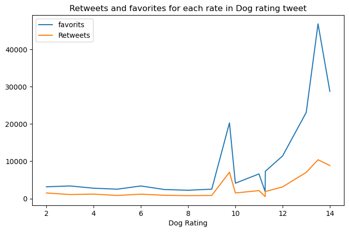

```python
# creat line chart and style it to show the result :
plt.figure(figsize=(8, 5), dpi=100)

plt.title('Retweets and favorites for each rate in Dog rating tweet')
plt.xlabel('Dog Rating')
plt.plot(favorite_group.index  , favorite_group  , label = 'favorits')
plt.plot(retweet_group.index  , retweet_group ,  label = 'Retweets')
plt.legend()
```

- it seems that tweets with rating 2 to 9 have the same retweet and favorite however form 10 we can see its incresed and the peak is around 14 so we can say that tweet with rating above 9 have more chance to be retweeted and favorited.

##### how the populriaty of this account has icreased over time ?

```python
# using groupby method to store rating mean for each rating
visualize_df['created_at'] = visualize_df['created_at'].astype('datetime64[ns]')
populiraty = visualize_df.groupby('created_at')[['retweet_count','favorite_count']].mean()

#populiraty data frame will have newa coulmn named populiraty to have one measuremnt will use in the second chart
populiraty['populiraty'] = populiraty['favorite_count'] / populiraty['retweet_count']
```

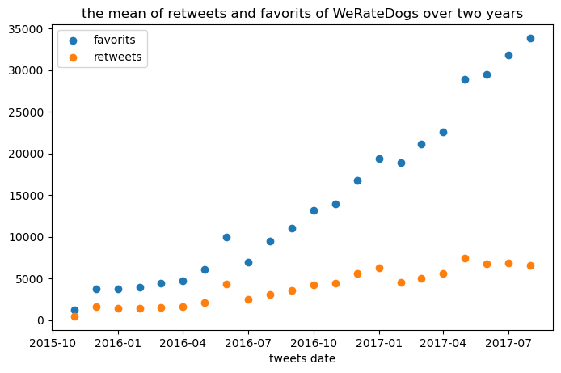

```python
# creat scatter chart and style it to show the result :
plt.figure(figsize=(8, 5), dpi=100)
plt.title('the mean of retweets and favorits of WeRateDogs over two years')
plt.xlabel('tweets date')
plt.scatter(populiraty.index , populiraty['favorite_count'] , label = 'favorits')
plt.scatter(populiraty.index , populiraty['retweet_count'] , label = 'retweets')
plt.legend()
```

- there are positive correlation in tweets and favorites with date witch indicate that popularity of WeRateDogs account is increasing over time

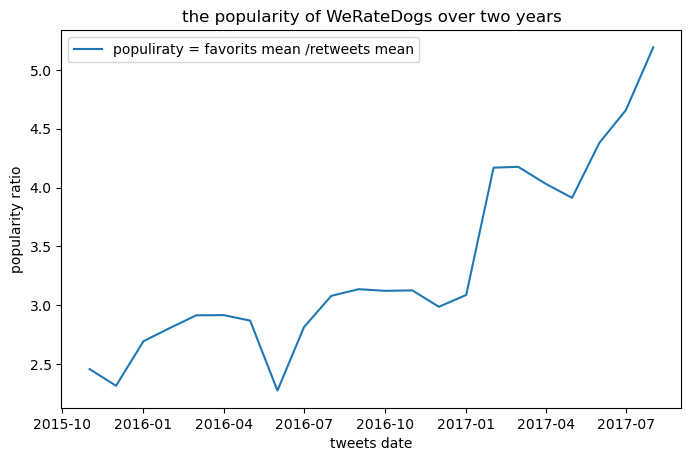

```python
# now lets see the popularity in chart
# popularity  = favorits mean /retweets mean

plt.figure(figsize=(8, 5), dpi=100)
plt.title('the popularity of WeRateDogs over two years')
plt.xlabel('tweets date')
plt.ylabel('popularity ratio')
plt.plot(populiraty.index , populiraty['populiraty'] , label='populiraty = favorits mean /retweets mean')
plt.legend()
```

- as we see in the frist chart this chart ensure the fact of WeRateDogs account is increasing , they started with 2.5 populiraty in 2015 and in 2017 they reach almost 5 populiraty

##### what are the top 100 rating dogs and thier type ?

```python
# extract the top100 rata dogs form the data frame
top100_index = visualize_df['rating_numerator'].sort_values(ascending = False)[0:100].index
top100_df = visualize_df.loc[top100_index]
# use group by to see the number of socre for the top100
top100_rating = top100_df.groupby(['rating_numerator'])['dog_type'].count()
top100_rating
```

```
rating_numerator
13.0    75
13.5     1
14.0    24
Name: dog_type, dtype: int64
```

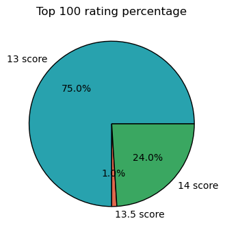

```python
# create pie chart to repreasent the top 100 rating score
labels = ['13 score','13.5 score' , '14 score']
plt.figure(dpi=100)
colors = ['#28A2AE' , '#DF684D' , '#3AA761' ]
plt.pie(top100_rating , labels = labels , colors = colors , wedgeprops={'edgecolor' : 'black'} , autopct = '%1.1f%%')
plt.title("Top 100 rating percentage")
```

- we cannt answer the question by this chart but it shows us that the highest score is 14 and only 24 dogs from 1600 have it

```python
# use group by to isolate the mean socre and the number of score
top100_dogtype_score = top100_df.groupby('dog_type')['rating_numerator'].mean()
top100_dogtype_number = top100_df.groupby('dog_type')['rating_numerator'].count()
```

```python
# create two list so we can use the dog type and its mean score in x-aixs in the chart
list_of_number = list(top100_dogtype_score.index)
list_of_score = list(top100_dogtype_score)

x_axis = []

# this loop will merge the two list to form one string that have the dog type and its mean score.
for i in range(len(list_of_score)):
    new_index = list_of_number[i]+' ({})'.format(round(list_of_score[i],1))
    x_axis.append(new_index)
```

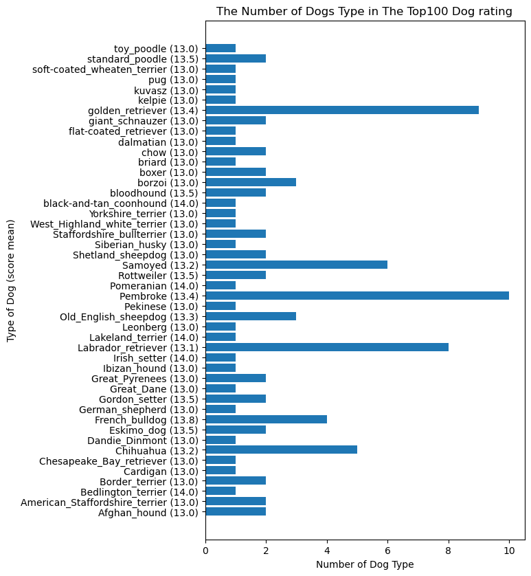

```python
# creat horizntal bar to display the result
plt.figure(figsize=(6, 10), dpi=100)
plt.barh(x_axis , top100_dogtype_number)
plt.title('The Number of Dogs Type in The Top100 Dog rating')
plt.xlabel('Number of Dog Type')
plt.ylabel('Type of Dog (score mean)')
```

- there are so many dog type sharing the top 100 witch indcate that there are no relation btween a doge type and its rating however we have two dog type that have high number in top100 golden_retriever with 9 with mean score of 13.4 and pembroke with 10 and mean score of 13.4 so these two type of dogs have high chance to rated high.

##### what are the probliblty of having golden_retriever dog type in a new tweet ?

P(golden etriever)

```python
(visualize_df['dog_type'] == 'golden_retriever').sum() / visualize_df['dog_type'].count()
```

```
0.09323040380047506
```

- the probliblty of having golden_retriever dog type in a new tweet is 9.32 %

##### what are the probliblty of hving the rate (12) given that the dog type is Labrador retriever ?

P(12 | Labrador_retriever)

frist : P(12 | Labrador_retriever) = (P(Labrador_retriever | 12) * P(12)) / P(Labrador_retriever)

```python
p_Labrador_retriever_given_12 = (visualize_df[visualize_df['rating_numerator'] == 12]['dog_type'] == 'Labrador_retriever').sum()\
                                /(visualize_df[visualize_df['rating_numerator'] == 12]['dog_type'].count())
p_Labrador_retriever_given_12
```

```
0.07276995305164319
```

P(Labrador_retriever | 12) = 7.27%

```python
P_12 = (visualize_df['rating_numerator'] == 12).sum() / visualize_df['rating_numerator'].count()
P_12
```

```
0.2529691211401425
```

P(12) = 25.29%

```python
p_Labrador_retriever = (visualize_df['dog_type'] == 'Labrador_retriever').sum() / visualize_df['dog_type'].count()
p_Labrador_retriever
```

```
0.06413301662707839
```

P(Labrador_retriever) = 6.41%

```python
(p_Labrador_retriever_given_12 * P_12) / p_Labrador_retriever
```

```
0.287037037037037
```

the probliblty of hving the rate (12) given that the dog type is Labrador retriever = 28.7%